This report conducts the initial exploration of the data set of the banff-2018-hackathon

```
Observations: 4,346,649
Variables: 34
$ ABDERR             <fct> Non-Aboriginal Identity, Non-Aboriginal Identity, Non-Aboriginal Ide...
$ ABIDENT            <fct> Non-Aboriginal identity population, Non-Aboriginal identity populati...
$ ADIFCLTY           <fct> No, No, No, No, No, No, No, No, No, No, No, No, No, No, No, No, No, ...
$ CITSM              <fct> Not a Canadian citizen by birth, Not a Canadian citizen by birth, Ca...
$ COWD               <fct> Paid Worker - Working for wages, salary, tips or commission, Paid Wo...
$ DISABFL            <fct> No, No, Yes, sometimes, No, No, No, No, No, Yes, sometimes, No, No, ...
$ DISABIL            <fct> No difficulty with daily activities and no reduced activities, No di...
$ DVISMIN            <fct> Not a visible minority, Not a visible minority, Not a visible minori...
$ FOL                <fct> English only, English only, French only, English only, English only,...
$ FPTIM              <fct> NA, NA, NA, NA, NA, NA, NA, NA, NA, NA, NA, NA, NA, NA, NA, NA, NA, ...
$ GENSTPOB           <fct> 1st generation - Respondent born outside Canada, 1st generation - Re...
$ HCDD               <fct> Bachelors degree, University certificate or diploma below bachelor l...
$ IMMDER             <fct> Immigrants, Immigrants, Non-immigrants, Non-immigrants, Non-immigran...
```

[output cut: 21 more lines]

This chunk will subset the data

```r
# this chunk is called by ./reports/eda-1/eda-1a-first-gen-immigrant.Rmd
ds <- ds %>%
  # dplyr::filter(PR %in% selected_provinces) %>%
  dplyr::filter(IMMDER   == "Immigrants") %>%
  dplyr::filter(GENSTPOB == "1st generation - Respondent born outside Canada")
```

# group( demographic )

## SEX

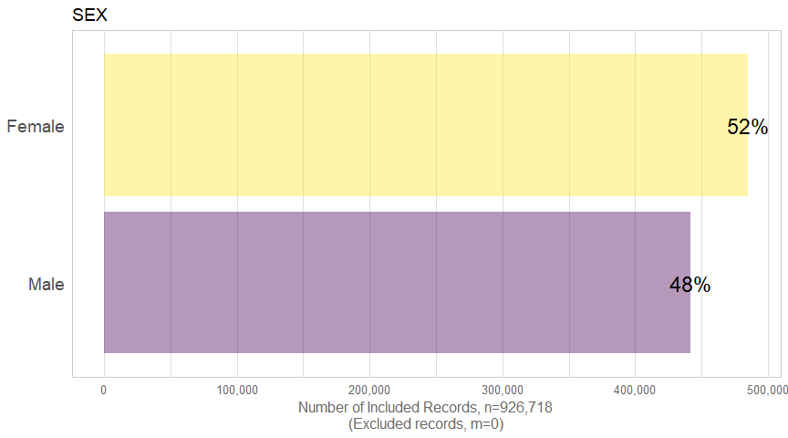

$SEX $SEX$levels 1 2 “Female” “Male”

$SEX$label [1] “Sex”

$SEX$description [1] “Sex”

## age_group

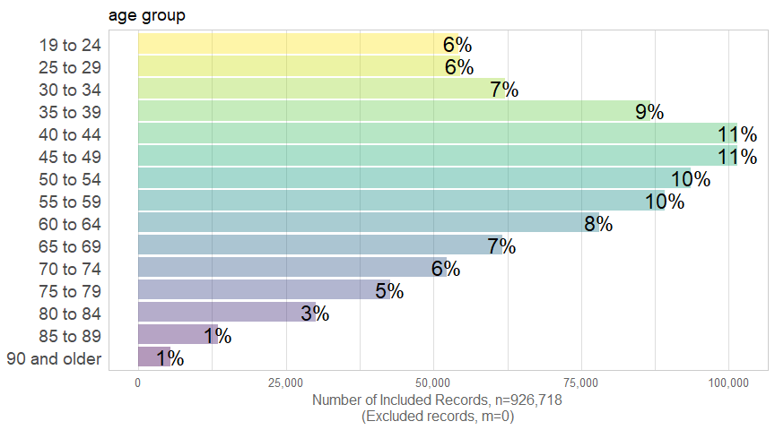

$age_group $age_group$levels 1 2 3 4 5 6 “19 to 24” “25 to 29” “30 to 34” “35 to 39” “40 to 44” “45 to 49” 7 8 9 10 11 12 “50 to 54” “55 to 59” “60 to 64” “65 to 69” “70 to 74” “75 to 79” 13 14 15 “80 to 84” “85 to 89” “90 and older”

$age_group$label [1] “Age”

$age_group$description [1] “Age: grouped”

## MARST

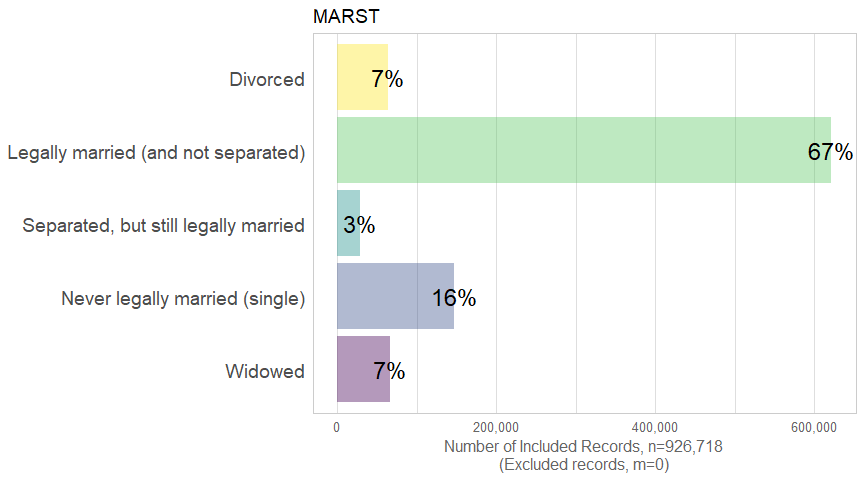

$MARST $MARST$levels 1 2 “Divorced” “Legally married (and not separated)” 3 4 “Separated, but still legally married” “Never legally married (single)” 5 “Widowed”

$MARST$label [1] “Marital status”

$MARST$description [1] “Marital Status: Refers to the legal marital status of the person.”

## EFCNT_PP_R

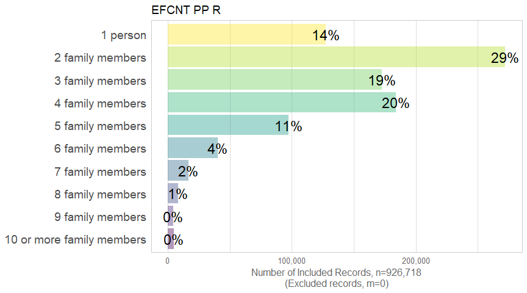

$EFCNT_PP_R $EFCNT_PP_R$levels 1 2 3 “1 person” “2 family members” “3 family members” 4 5 6 “4 family members” “5 family members” “6 family members” 7 8 9 “7 family members” “8 family members” “9 family members” 10 “10 or more family members”

$EFCNT_PP_R$label [1] “Family size”

$EFCNT_PP_R$description [1] “Number of persons in the family: Refers to the number of persons in the individuals family.”

## KID_group

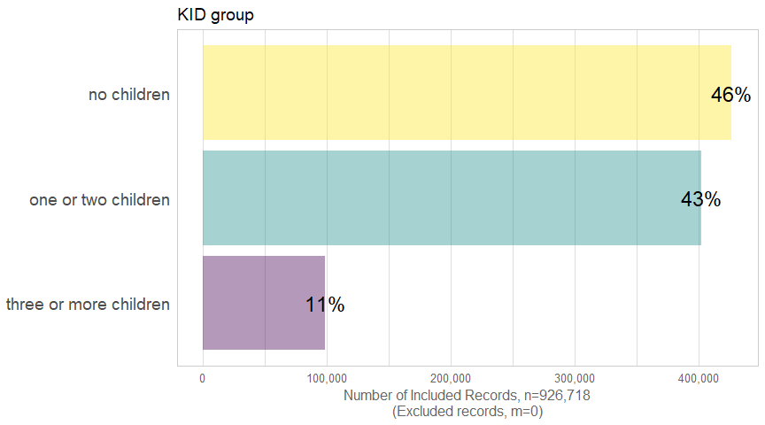

$KID_group $KID_group$levels 1 2 3 “no children” “one or two children” “three or more children”

$KID_group$label [1] “Number of children”

$KID_group$description [1] “Children, total number in family (grouped)”

## PR

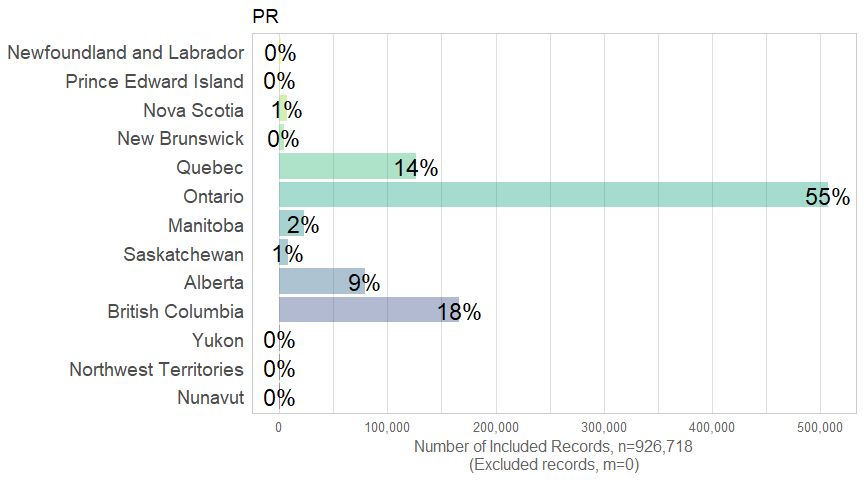

$PR $PR$levels 10 11 12 “Newfoundland and Labrador” “Prince Edward Island” “Nova Scotia” 13 24 35 “New Brunswick” “Quebec” “Ontario” 46 47 48 “Manitoba” “Saskatchewan” “Alberta” 59 60 61 “British Columbia” “Yukon” “Northwest Territories” 62 “Nunavut”

$PR$label [1] “Province of residence”

$PR$description [1] “Province or territory of residence”

# group( identity )

## FOL

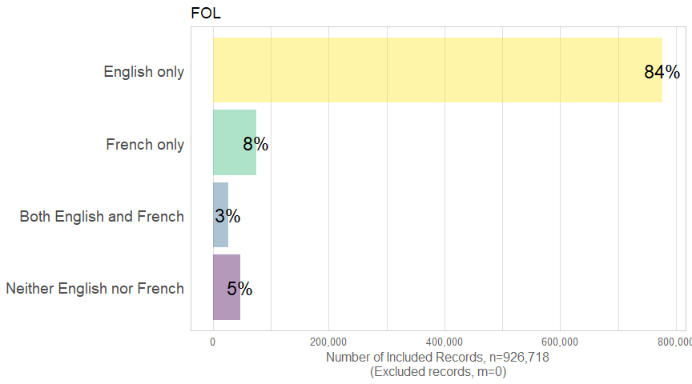

$FOL $FOL$levels 1 2 3 “English only” “French only” “Both English and French” 4 “Neither English nor French”

$FOL$label [1] “First language”

$FOL$description [1] “First official language: First official language spoken”

## OLN

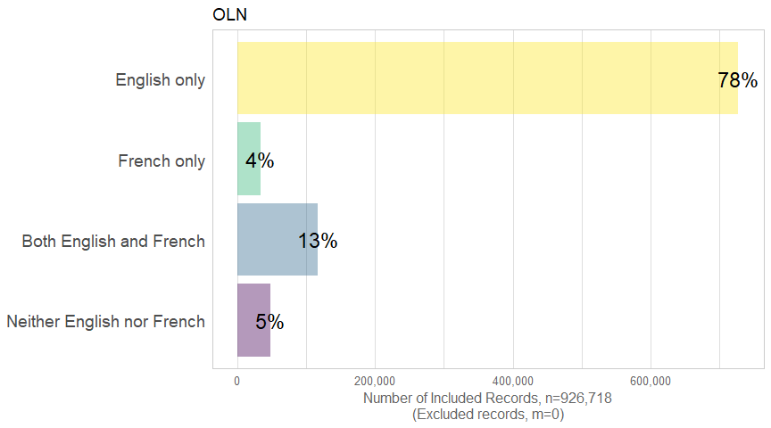

$OLN $OLN$levels 1 2 3 “English only” “French only” “Both English and French” 4 “Neither English nor French”

$OLN$label [1] “Conversational language”

$OLN$description [1] “Official language: Refers to the ability to conduct a conversation in English only, in French only, in both English and French or in none of the official languages of Canada”

## DVISMIN

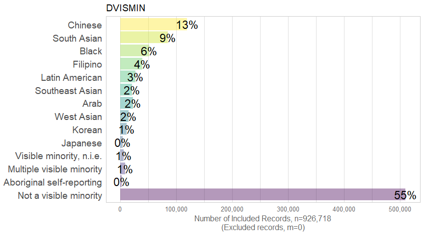

$DVISMIN $DVISMIN$levels 1 2 3 “Chinese” “South Asian” “Black” 4 5 6 “Filipino” “Latin American” “Southeast Asian” 7 8 9 “Arab” “West Asian” “Korean” 10 11 12 “Japanese” “Visible minority, n.i.e.” “Multiple visible minority” 13 14 “Aboriginal self-reporting” “Not a visible minority”

$DVISMIN$label [1] “Visible minority”

$DVISMIN$description [1] “Visible minority: Refers to the visible minority group to which the respondent belongs. The Employment Equity Act defines visible minorities as ‘persons, other than Aboriginal peoples, who are non-Caucasian in race or non-white in colour’.”

## ABDERR

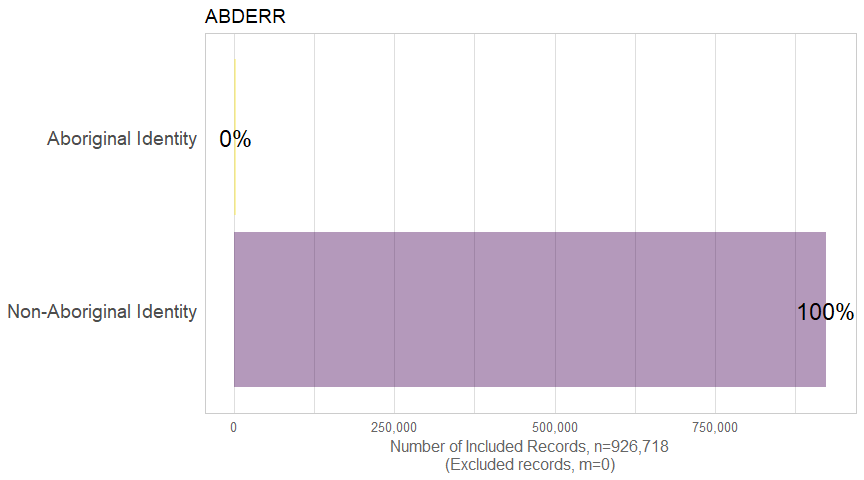

$ABDERR $ABDERR$levels 1 2 “Aboriginal Identity” “Non-Aboriginal Identity”

$ABDERR$label [1] “Aboriginal Status”

$ABDERR$description [1] “Aboriginal identity status (detailed measure): Refers to those persons who reported identifying who reported identifying with at least one Aboriginal group (North American Indian, Métis or Inuit”

## ABIDENT

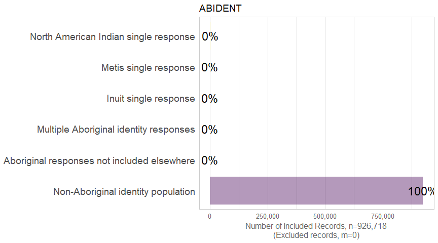

$ABIDENT $ABIDENT$levels 1 2 “North American Indian single response” “Metis single response” 3 4 “Inuit single response” “Multiple Aboriginal identity responses” 5 6 “Aboriginal responses not included elsewhere” “Non-Aboriginal identity population”

$ABIDENT$label [1] “Aboriginal Identity (detail)”

$ABIDENT$description [1] “Aboriginal identity status (detailed measure): Refers to those persons who reported identifying who reported identifying with at least one Aboriginal group (North American Indian, Métis or Inuit)”

# group( economic )

## HCDD

[figure not shown]

$HCDD $HCDD$levels 1 “None” 2 “High school graduation certificate or equivalency certificate” 3 “Other trades certificate or diploma” 4 “Registered apprenticeship certificate” 5 “College, CEGEP or other non-university certificate or diploma from a program of 3 months to less than 1 year” 6 “College, CEGEP or other non-university certificate or diploma from a program of 1 year to 2 years” 7 “College, CEGEP or other non-university certificate or diploma from a program of more than 2 years” 8 “University certificate or diploma below bachelor level” 9 “Bachelors degree” 10 “University certificate or diploma above bachelor level” 11 “Degree in medicine, dentistry, veterinary medicine or optometry” 12 “Masters degree” 13 “Earned doctorate degree”

$HCDD$label [1] “Highest degree”

$HCDD$description [1] “Highest certificate, diploma or degree: Information indicating the persons most advanced certificate, diploma or degree.”

## COWD

[figure not shown]

$COWD $COWD$levels 1 “Unpaid family workers - Worked without pay for a relative in a family business or farm” 2 “Paid worker - Originally self-employed without paid help, incorporated” 3 “Paid worker - Originally self-employed with paid help, incorporated” 4 “Paid Worker - Working for wages, salary, tips or commission” 5 “Self-employed without paid help, not incorporated” 6 “Self-employed with paid help, not Incorporated” 7 “Not applicable”

$COWD$label [1] “Class of worker”

$COWD$description [1] “Class of worker: Refers to the classification of respondents who reported a job”

## NOCSBRD

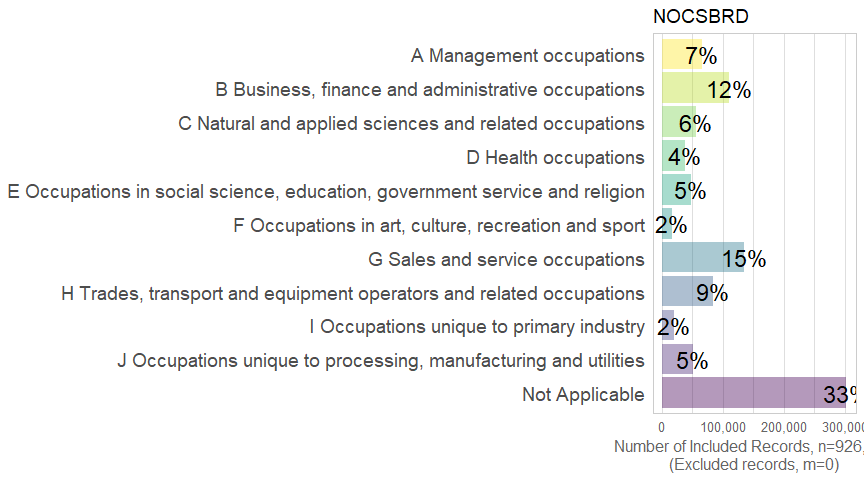

$NOCSBRD $NOCSBRD$levels 1 “A Management occupations” 2 “B Business, finance and administrative occupations” 3 “C Natural and applied sciences and related occupations” 4 “D Health occupations” 5 “E Occupations in social science, education, government service and religion” 6 “F Occupations in art, culture, recreation and sport” 7 “G Sales and service occupations” 8 “H Trades, transport and equipment operators and related occupations” 9 “I Occupations unique to primary industry” 10 “J Occupations unique to processing, manufacturing and utilities” 11 “Not Applicable”

$NOCSBRD$label [1] “Occupation (broad)”

$NOCSBRD$description [1] “Occupation broad categories: Refers to the kind of work persons were doing during the reference week, as determined by their kind of work and the description of the main activities in their job.”

## TRMODE

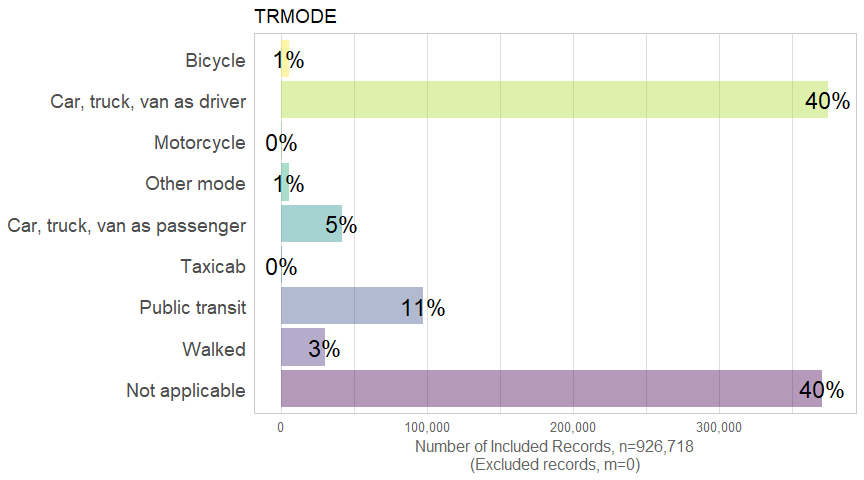

$TRMODE $TRMODE$levels 1 2 3 “Bicycle” “Car, truck, van as driver” “Motorcycle” 4 5 6 “Other mode” “Car, truck, van as passenger” “Taxicab” 7 8 9 “Public transit” “Walked” “Not applicable”

$TRMODE$label [1] “Ride to work”

$TRMODE$description [1] “Mode of transportation to work: Refers to the mode of transportation to work of respondents 15 years of age and over who have worked since January 1, 2005.”

## LOINCA

[figure not shown]

$LOINCA $LOINCA$levels 1 “non-low income” 2 “low income” 3 “Concept not applicable (economic familes, persons not in economic families in the Yukon, NWT, Nunavut and on Indian Reserves)”

$LOINCA$label [1] “Low income A”

$LOINCA$description [1] “Low income status (after taxes): Refers to the low income status of the respondent in relation to Statistics Canadas Low Income before tax cutoffs”

## LOINCB

[figure not shown]

$LOINCB $LOINCB$levels 1 “non-low income” 2 “low income” 3 “Concept not applicable (economic familes, persons not in economic families in the Yukon, NWT, Nunavut and on Indian Reserves)”

$LOINCB$label [1] “Low income B”

$LOINCB$description [1] “Low income status (before taxes): Refers to the low income status of the respondent in relation to Statistics Canadas Low Income before tax cutoffs”

## d_licoratio_da_bef

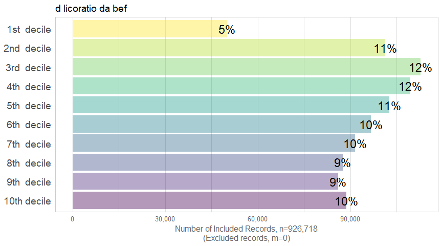

$d_licoratio_da_bef $d_licoratio_da_bef$levels 1 2 3 4 5 6 7 “1st decile” “2nd decile” “3rd decile” “4th decile” “5th decile” “6th decile” “7th decile” 8 9 10 “8th decile” “9th decile” “10th decile”

$d_licoratio_da_bef$label [1] “Low income decile”

$d_licoratio_da_bef$description [1] “Low-income area-based deciles: The ratio of total income to Statistics Canada low-income cut-offs for the applicable family size and community size. Ratios were calculated by each CMA/CA or by provincial rural residual levels and divided into the regional level deciles for before tax income.”

## RUINDFG

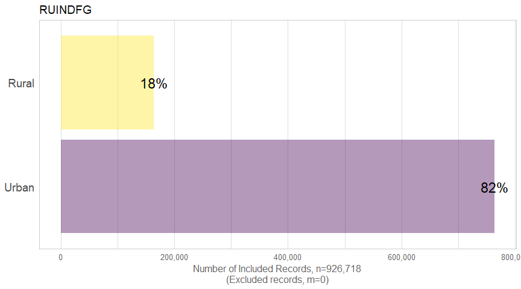

$RUINDFG $RUINDFG$levels 1 2 “Rural” “Urban”

$RUINDFG$label [1] “Rural status”

$RUINDFG$description [1] “Rural urban classification: Blocks falling inside urban areas are classified as urban. Blocks falling outside of urban areas are classified as rural.”

## RPAIR

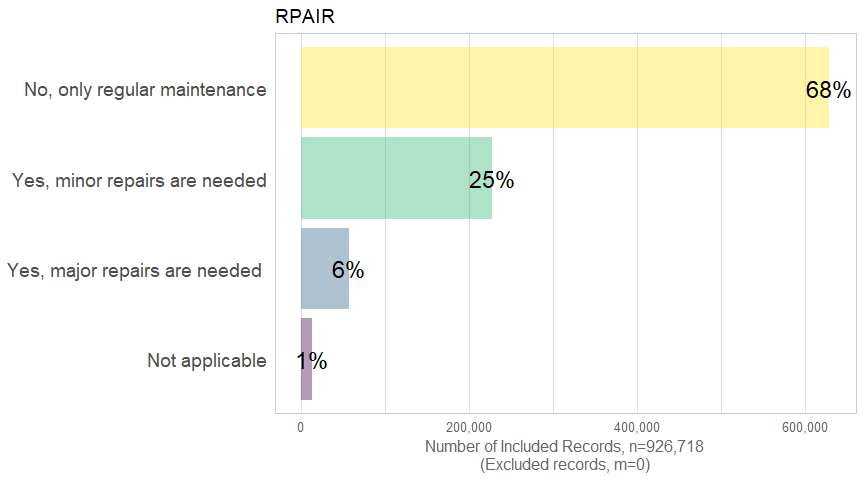

$RPAIR $RPAIR$levels 1 2 3 “No, only regular maintenance” “Yes, minor repairs are needed” “Yes, major repairs are needed” 4 “Not applicable”

$RPAIR$label [1] “Need repair of dwelling?”

$RPAIR$description [1] “Condition of dwelling: Refers to whether, in the judgement of the respondent, the dwelling requires any repairs (excluding desirable remodelling or additions).”

# group( immigration )

## POBDER

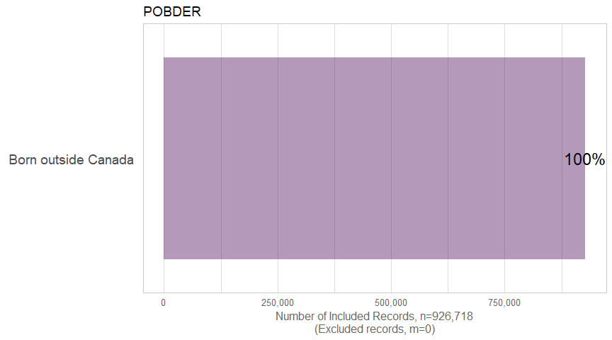

$POBDER $POBDER$levels 1 2 3 " Born in province of residence" " Born in another province" " Born outside Canada "

$POBDER$label [1] “Place of birth”

$POBDER$description [1] “Place of birth: Indicates whether the respondent was born in the same province that they lived in at the time of survey, born in a different province than they lived in at the time of the survey or born outside Canada.”

## DPOB11N

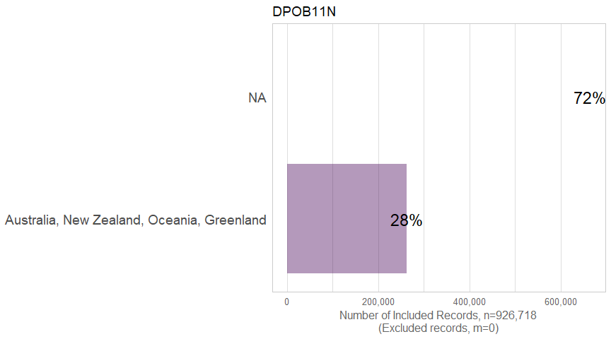

$DPOB11N $DPOB11N$levels 01 02 “non-immigrant” “Latin America and Caribbean” 03 04 “Western Europe” “Eastern Europe” 05 06 “Sub-Saharan Africa” “North Africa, South West Asia, Middle East” 07 08 “South Asia” “Southeast Asia” 09 10 “East Asia (incl Singapore)” “Australia, New Zealand, Oceania, Greenland”

$DPOB11N$label [1] “Contry of birth”

$DPOB11N$description [1] “Country of birth: Refers to the country of birth for those respondents not born in Canada”

## IMMDER

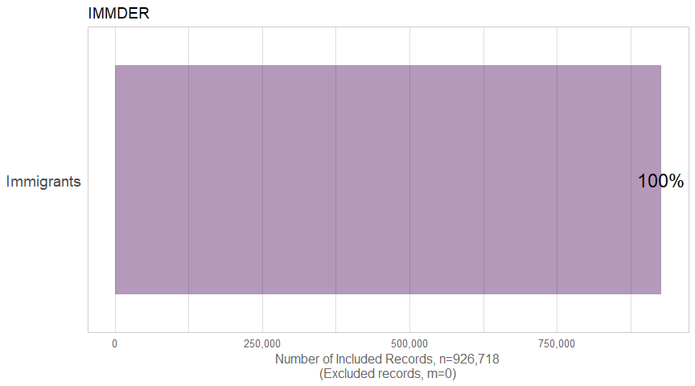

$IMMDER $IMMDER$levels 1 2 3 “Immigrants” “Non-permanent residents” “Non-immigrants”

$IMMDER$label [1] “Immigration status”

$IMMDER$description [1] “Immigration status: Indicates whether the respondent is a non-immigrant, an immigrant or a non-permanent resident.”

## AGE_IMM_R_group

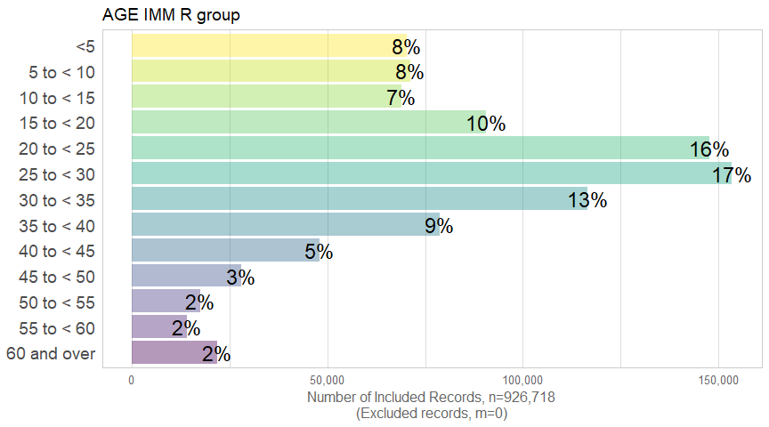

$AGE_IMM_R_group $AGE_IMM_R_group$levels 1 2 “<5” " 5 to < 10" 3 4 “10 to < 15” “15 to < 20” 5 6 “20 to < 25” “25 to < 30” 7 8 “30 to < 35” “35 to < 40” 9 10 “40 to < 45” “45 to < 50” 11 12 “50 to < 55” “55 to < 60” 13 14 “60 and over” “Non-permanent residents” 15 “Non-immigrants and institutional residents”

$AGE_IMM_R_group$label [1] “Age at immigration”

$AGE_IMM_R_group$description [1] “Age at immigration (grouped): Refers to the age at which the respondent first obtained landed immigrant status. A landed immigrant is a person who has been granted the right to live in Canada permanently by immigration authorities.”

## YRIM_group

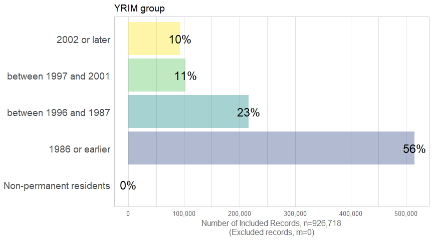

$YRIM_group $YRIM_group$levels 1 2 “2002 or later” “between 1997 and 2001” 3 4 “between 1996 and 1987” “1986 or earlier” 5 6 “Non-permanent residents” “Non-immigrants and institutional residents”

$YRIM_group$label [1] “Year came to Canada”

$YRIM_group$description [1] “Year of immigration: Refers to the year landed immigrant status was first obtained in Canada. Includes immigrants who landed in Canada prior to the survey collection.”

## CITSM

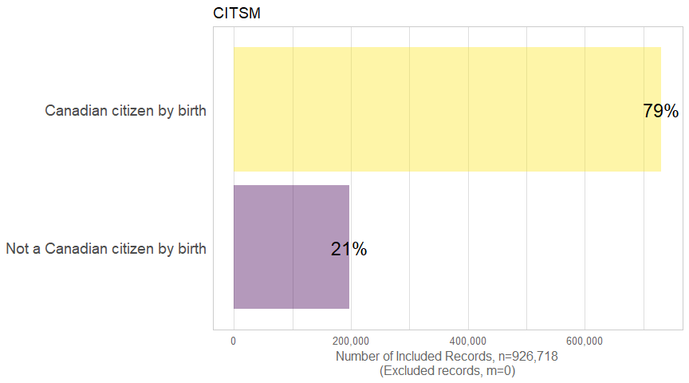

$CITSM $CITSM$levels 1 2 “Canadian citizen by birth” “Not a Canadian citizen by birth”

$CITSM$label [1] “Citizen of Canada”

$CITSM$description [1] “Citizenship status: Refers to the legal citizenship status of the respondent as being ‘’Canadian citizen by birth’’ or something else.”

## GENSTPOB

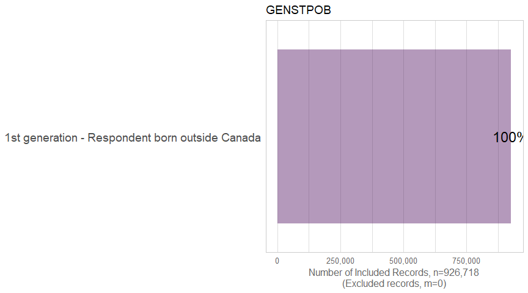

$GENSTPOB $GENSTPOB$levels 1 “1st generation - Respondent born outside Canada” 2 “2nd generation - Respondent born in Canada of at least one foreign-born parent” 3 “3rd generation - Respondent born in Canada and both parents born in Canada”

$GENSTPOB$label [1] “Generation in Canada”

$GENSTPOB$description [1] “Generation status: Refers to the generational status of the respondent, that is, 1st generation, 2nd generation or 3rd generation or more.Generation status is derived from place of birth of respondent, place of birth of father and place of birth of mother.”

# group( health )

## ADIFCLTY

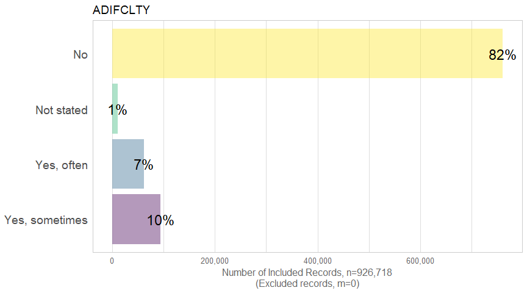

$ADIFCLTY $ADIFCLTY$levels 1 2 3 4 “No” “Not stated” “Yes, often” “Yes, sometimes”

$ADIFCLTY$label [1] “Problems with ADL”

$ADIFCLTY$description [1] “Difficulties with activities of daily living: Difficulty with activities of daily living such as hearing, seeing, communicating, walking, climbing stairs, bending, learning or doing any similar activities.”

## DISABFL

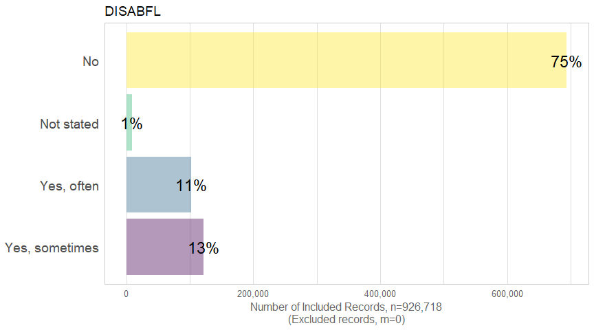

$DISABFL $DISABFL$levels 1 2 3 4 “No” “Not stated” “Yes, often” “Yes, sometimes”

$DISABFL$label [1] “Problems with ADL”

$DISABFL$description [1] “Difficulties with activities of daily living: Refers to difficulty with daily activities and/or a physical condition or mental condition or health problem that reduces the amount or kind of activity that a person can do at home, at work or school or in other activities (e.g., transportation, leisure).”

## DISABIL

[figure not shown]

$DISABIL $DISABIL$levels 1 “Difficulty with daily activities & activities reduced at home and in other activities” 2 “Difficulty with daily activities & activities reduced at home and at work/school” 3 “Difficulty with daily activities & activities reduced at home at work/school and in other activities” 4 “Difficulty with daily activities & activities reduced at work/school and in other activities” 5 “Difficulty with daily activities & activities reduced at home” 6 “Difficulty with daily activities & activities reduced in other activities” 7 “Difficulty with daily activities & activities reduced at work/school” 8 “Difficulty with daily activities” 9 “No difficulty with daily activities and no reduced activities” 10 “Activities reduced at home and in other activities” 11 “Activities reduced at home and at work/school” 12 “Activities reduced at home, at work/school and in other activities” 13 “Activities reduced at work/school and in other activities” 14 “Activities reduced at home” 15 “Activities reduced in other activities” 16 “Activities reduced at work/school” 17 “Not stated”

$DISABIL$label [1] “Problems with ADL (by type)”

$DISABIL$description [1] “Difficulties with activities of daily living by type: Refers to having at least one of the activity difficulties/reductions, or having two or more in different combinations.”

## S_DEAD

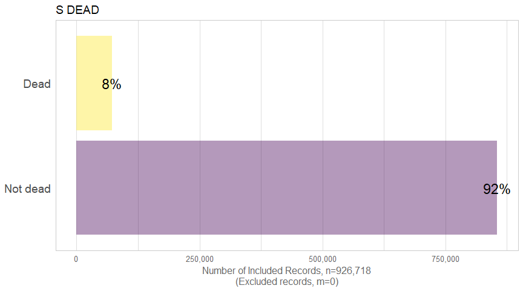

$S_DEAD $S_DEAD$levels 1 2 “Dead” “Not dead”

$S_DEAD$label [1] “Dead in X years?”

$S_DEAD$description [1] “Mortality status: Refers to whether or not the respondent died during the X years following the survey response”

## COD1

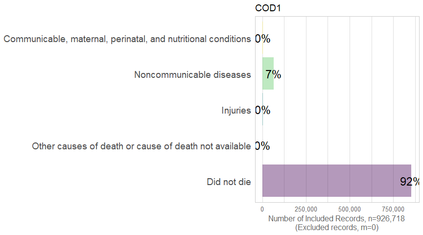

$COD1 $COD1$levels 1 “Communicable, maternal, perinatal, and nutritional conditions” 2 “Noncommunicable diseases” 3 “Injuries” 4 “Other causes of death or cause of death not available” 5 “Did not die”

$COD1$label [1] “Cause of death (short)”

$COD1$description [1] “Cause of death according to Global Burden of Disease Level 1 codes (with ICD-10 codes for comparison, see COD1_CODES)”

## COD2

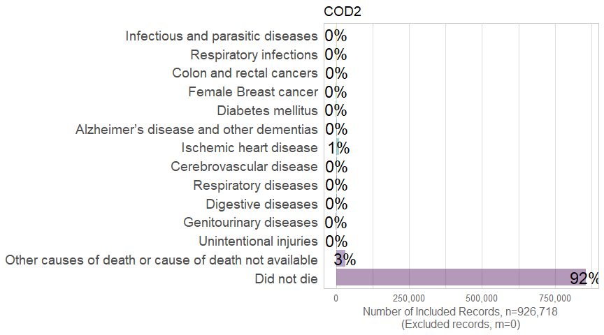

$COD2 $COD2$levels 1 “Infectious and parasitic diseases” 2 “Respiratory infections” 3 “Colon and rectal cancers” 4 “Female Breast cancer” 5 “Diabetes mellitus” 6 “Alzheimer’s disease and other dementias” 7 “Ischemic heart disease” 8 “Cerebrovascular disease” 9 “Respiratory diseases” 10 “Digestive diseases” 11 “Genitourinary diseases” 12 “Unintentional injuries” 13 “Other causes of death or cause of death not available” 14 “Did not die”

$COD2$label [1] “Cause of death (long)”

$COD2$description [1] “Cause of death 2: Select causes of death according to Global Burden of Disease Level 2 codes (with ICD-10 codes for comparison, see COD2_CODES)”

# Session Information

```
Report rendered by koval at 2018-10-30, 17:52 -0700 in 31 seconds.
```